# SI 618 Homework 8

### The total points for this assignment is 100

```python
import pandas as pd
import seaborn as sns
import matplotlib.pyplot as plt
```

## The data:

- https://www.kaggle.com/terminus7/pokemon-challenge

> This data set contains two files.

> pokemon.csv: 800 Pokemon, including their number, name, first and second type, basic stats: HP, Attack, Defense, Special Attack, Special Defense, the game generation they were introduced in, and whether they had the "legendary" status.

> combats.csv: 50,000 simulated encounters between pairs of pokemon with the first pokemon to act, the other pokemon and the winner

## Guidance

- Show your code
- **Explain your answer**

### Q1. For 15 Points: Plot the pairs of different ability points (HP, Attack, Sp. Attack, Defense, etc.).

- Which abilities are most and least correlated?

```python
pokemon = pd.read_csv('pokemon.csv')
pokemon.head()
```

|  | # | Name | Type 1 | Type 2 | HP | Attack | Defense | Sp. Atk | Sp. Def | Speed | Generation | Legendary |
| --- | --- | --- | --- | --- | --- | --- | --- | --- | --- | --- | --- | --- |
| 0 | 1 | Bulbasaur | Grass | Poison | 45 | 49 | 49 | 65 | 65 | 45 | 1 | False |
| 1 | 2 | Ivysaur | Grass | Poison | 60 | 62 | 63 | 80 | 80 | 60 | 1 | False |
| 2 | 3 | Venusaur | Grass | Poison | 80 | 82 | 83 | 100 | 100 | 80 | 1 | False |
| 3 | 4 | Mega Venusaur | Grass | Poison | 80 | 100 | 123 | 122 | 120 | 80 | 1 | False |
| 4 | 5 | Charmander | Fire | NaN | 39 | 52 | 43 | 60 | 50 | 65 | 1 | False |

```python
combats = pd.read_csv('combats.csv')
combats.head()
```

|  | First_pokemon | Second_pokemon | Winner |
| --- | --- | --- | --- |
| 0 | 266 | 298 | 298 |
| 1 | 702 | 701 | 701 |
| 2 | 191 | 668 | 668 |
| 3 | 237 | 683 | 683 |
| 4 | 151 | 231 | 151 |

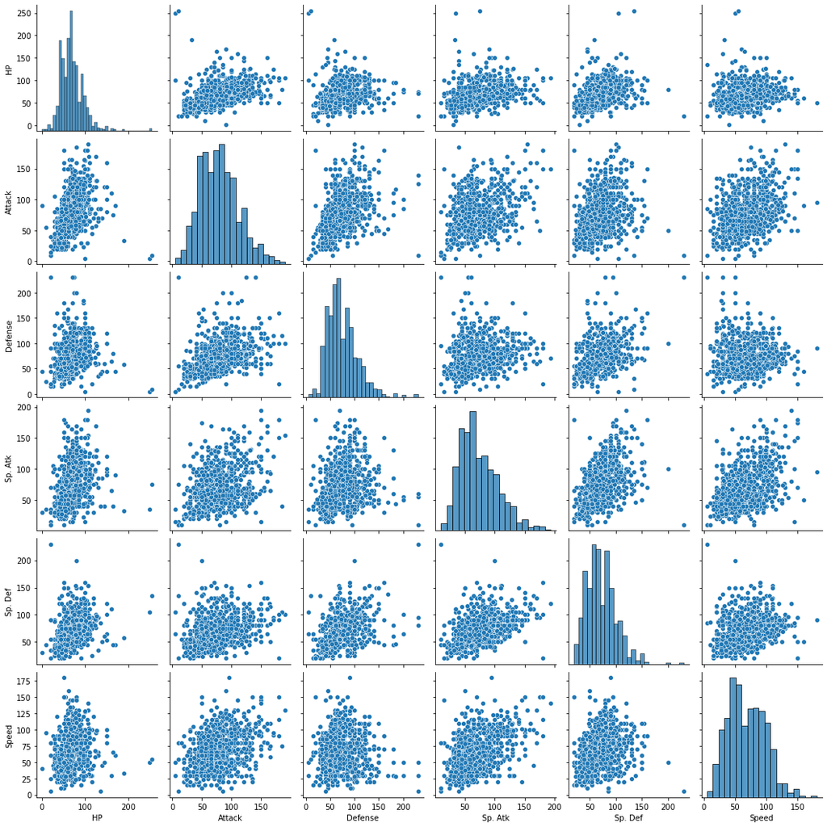

```python
df = pokemon[['HP', 'Attack', 'Defense', 'Sp. Atk', 'Sp. Def', 'Speed']]
sns.pairplot(df)
```

Most correlated: Sp. Atk and Sp. Def  
Least correlated: Defense and Speed

### Q2. For 15 Points: Plot the distribution of ability points per Pokémon type

- How would you describe each Pokémon type with different ability points as well as their overall ability score (sum of different abilities)? For simplicity, let's focus solely on pokemon that are type 1 (non-dual type pokemon)

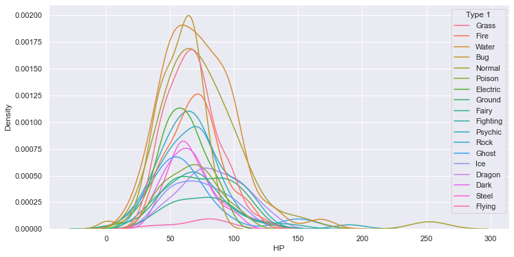

```python
sns.set(rc={"figure.figsize": (12, 6)})
sns.kdeplot(data=pokemon, x="HP", hue="Type 1")
```

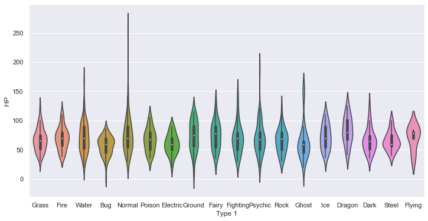

```python
sns.set(rc={"figure.figsize": (12, 6)})
sns.violinplot(x='Type 1', y='HP', data=pokemon)
```

It seems that Normal Pokemons may have higher HP, while Bug Pokemons may have lower HP.

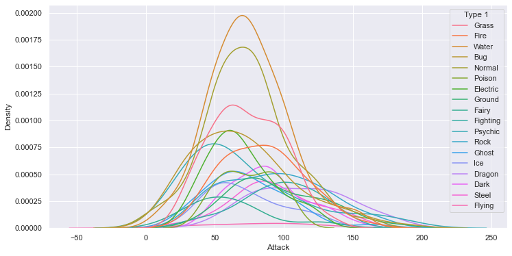

```python
sns.set(rc={"figure.figsize": (12, 6)})
sns.kdeplot(data=pokemon, x="Attack", hue="Type 1")
```

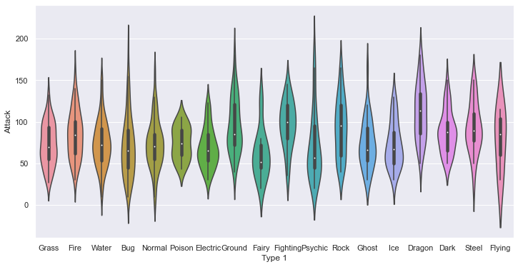

```python
sns.set(rc={"figure.figsize": (12, 6)})
sns.violinplot(x='Type 1', y='Attack', data=pokemon)
```

It seems that Psychic Pokemons may have the highest Attack, but overall Dragon Pokemons have a higher average attack.

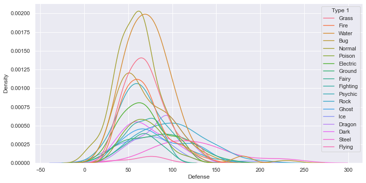

```python
sns.set(rc={"figure.figsize": (12, 6)})
sns.kdeplot(data=pokemon, x="Defense", hue="Type 1")
```

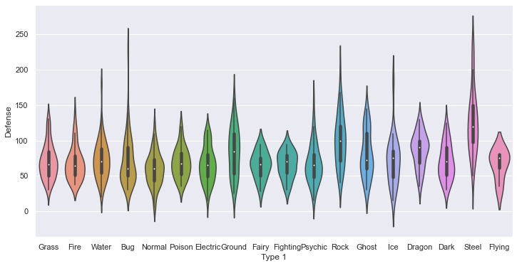

```python
sns.set(rc={"figure.figsize": (12, 6)})
sns.violinplot(x='Type 1', y='Defense', data=pokemon)
```

Steel Pokemons may have the highest defense and also the highest average defense.

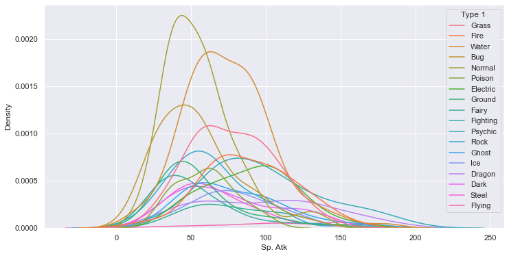

```python
sns.set(rc={"figure.figsize": (12, 6)})
sns.kdeplot(data=pokemon, x="Sp. Atk", hue="Type 1")
```

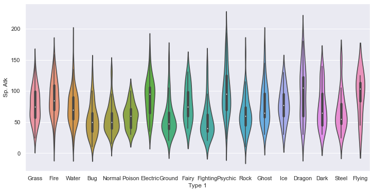

```python
sns.set(rc={"figure.figsize": (12, 6)})
sns.violinplot(x='Type 1', y='Sp. Atk', data=pokemon)
```

Both Psychic and Dragon Pokemons have higher average Sp. Atk.

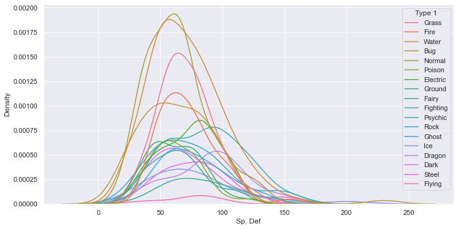

```python
sns.set(rc={"figure.figsize": (12, 6)})
sns.kdeplot(data=pokemon, x="Sp. Def", hue="Type 1")
```

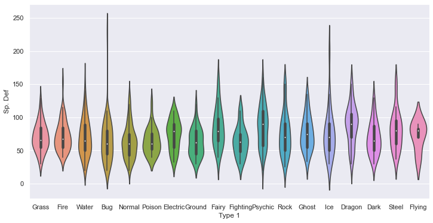

```python
sns.set(rc={"figure.figsize": (12, 6)})
sns.violinplot(x='Type 1', y='Sp. Def', data=pokemon)
```

Bug Pokemons may have extremely high Sp. Def, but overall Psychic Pokemons have the highest average Sp. Def.

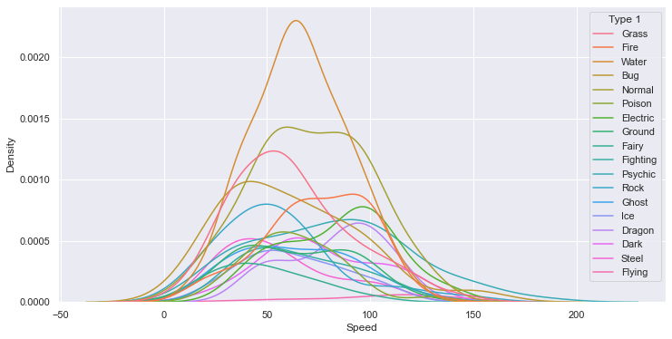

```python
sns.set(rc={"figure.figsize": (12, 6)})
sns.kdeplot(data=pokemon, x="Speed", hue="Type 1")
```

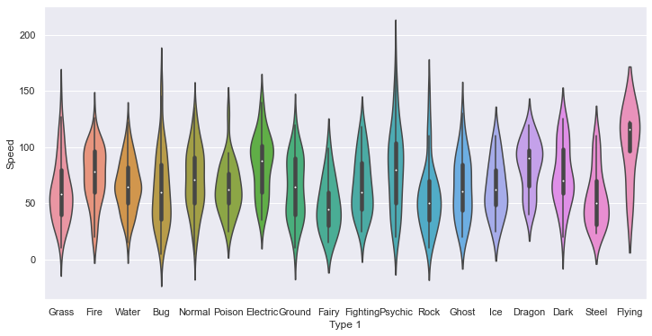

```python
sns.set(rc={"figure.figsize": (12, 6)})
sns.violinplot(x='Type 1', y='Speed', data=pokemon)
```

Psychic Pokemons may have extremely high speed, but overall Flying Pokemons have the highest average speed. Fairy Pokemons have the lowest average speed.

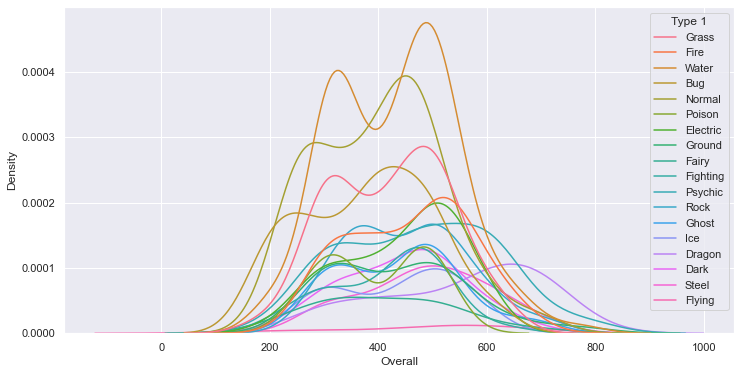

```python
pokemon['Overall'] = pokemon['HP'] + pokemon['Attack'] + pokemon['Defense'] + pokemon['Sp. Atk'] + pokemon['Sp. Def'] + pokemon['Speed']
sns.set(rc={"figure.figsize": (12, 6)})
sns.kdeplot(data=pokemon, x="Overall", hue="Type 1")
```

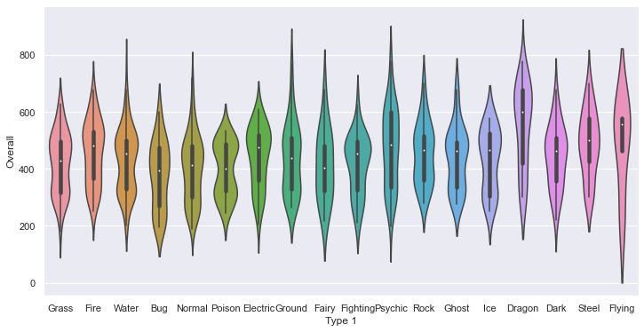

```python
sns.set(rc={"figure.figsize": (12, 6)})
sns.violinplot(x='Type 1', y='Overall', data=pokemon)
```

Dragon Pokemons have the highest average overall ability scores and the Pokemon with the highest overall ability score is also Dragon. The Pokemon with the lowest overall ability score is Flying.

### Q3. For 15 Points: Explore how the Pokémon in each generation differ from each other?

- Do you think designers of *Pokémon* tried to address different distributions of ability points in each generation?
- Plot the distributions of abilities in different generations. Compare the results and explain your findings in 4-5 sentences.

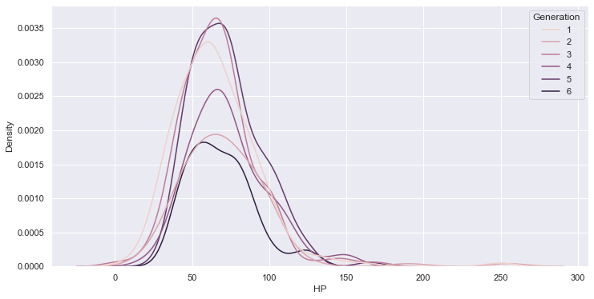

```python
sns.set(rc={"figure.figsize": (12, 6)})
sns.kdeplot(data=pokemon, x="HP", hue="Generation")
```

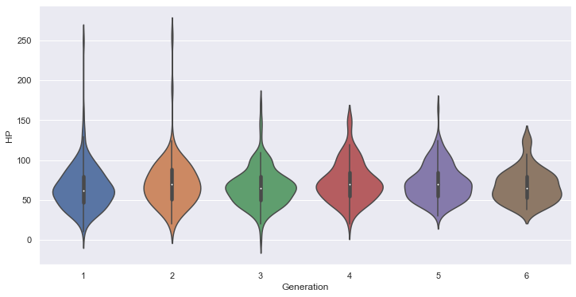

```python
sns.set(rc={"figure.figsize": (12, 6)})
sns.violinplot(x='Generation', y='HP', data=pokemon)
```

We can see that the average HP of several generations of Pokémon is not very different, but the first generation and the second generation have some extremely high HP individuals.

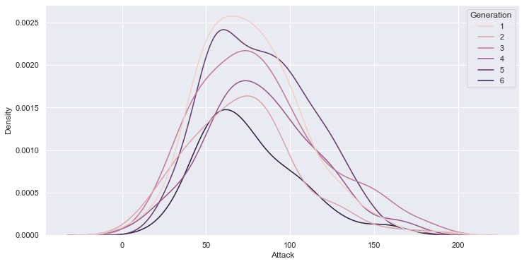

```python
sns.set(rc={"figure.figsize": (12, 6)})
sns.kdeplot(data=pokemon, x="Attack", hue="Generation")
```

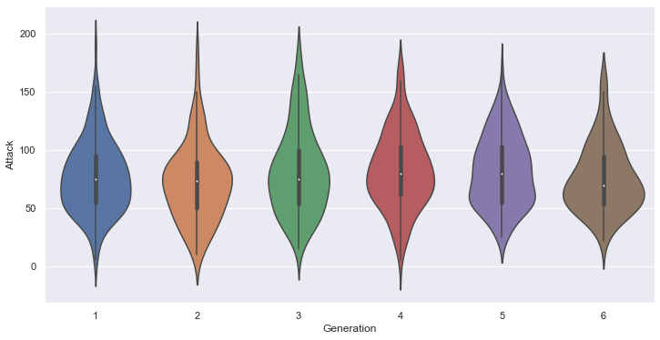

```python
sns.set(rc={"figure.figsize": (12, 6)})
sns.violinplot(x='Generation', y='Attack', data=pokemon)
```

We can see that the average value of the Attack of several generations of Pokémon is not very different, but overall with the increase in generation, the data distribution of the Attack is more concentrated

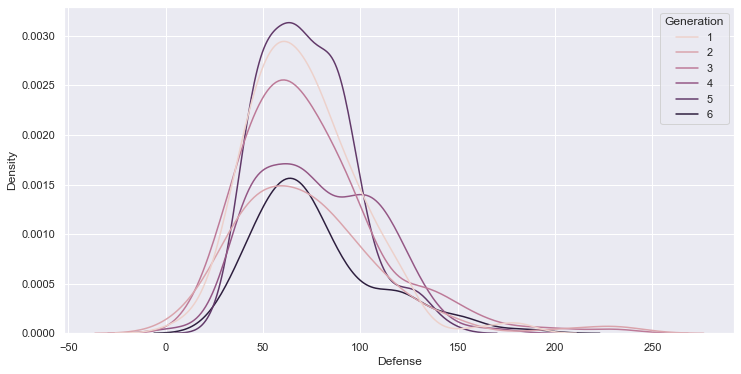

```python
sns.set(rc={"figure.figsize": (12, 6)})
sns.kdeplot(data=pokemon, x="Defense", hue="Generation")
```

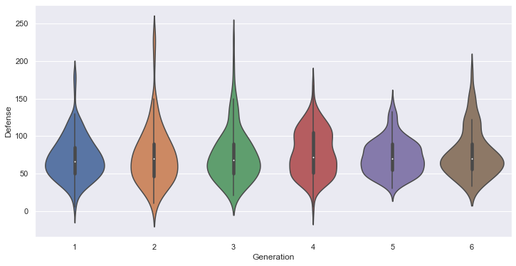

```python
sns.set(rc={"figure.figsize": (12, 6)})
sns.violinplot(x='Generation', y='Defense', data=pokemon)
```

We can see that the average value of the Defense of several generations of Pokémon is not very different, although there are some individuals with extremely large Defense values in the second generation.

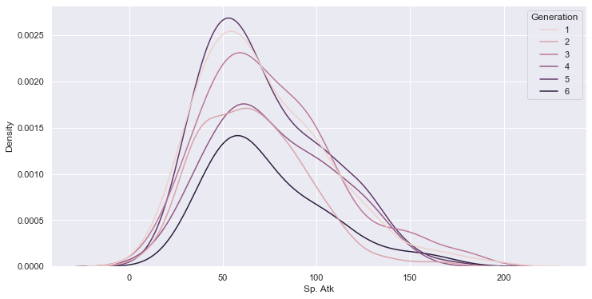

```python
sns.set(rc={"figure.figsize": (12, 6)})
sns.kdeplot(data=pokemon, x="Sp. Atk", hue="Generation")
```

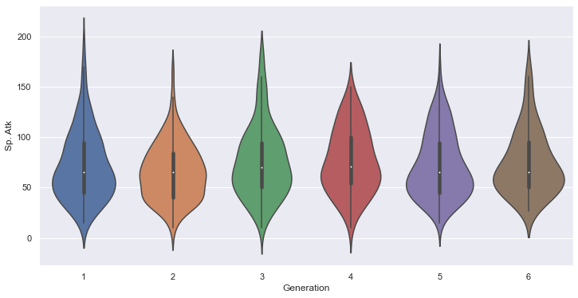

```python
sns.set(rc={"figure.figsize": (12, 6)})
sns.violinplot(x='Generation', y='Sp. Atk', data=pokemon)
```

We can see that the average value of the Sp. Atk of several generations of Pokémon is not very different, although there are some individuals with extremely large Sp. Atk values in the first generation.

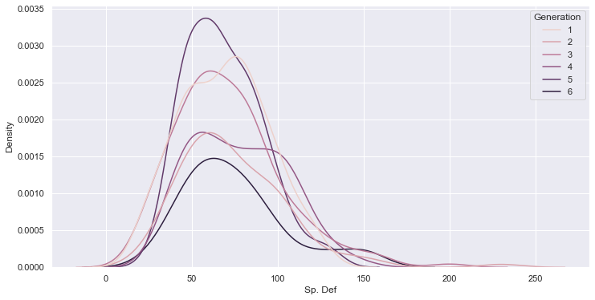

```python
sns.set(rc={"figure.figsize": (12, 6)})
sns.kdeplot(data=pokemon, x="Sp. Def", hue="Generation")
```

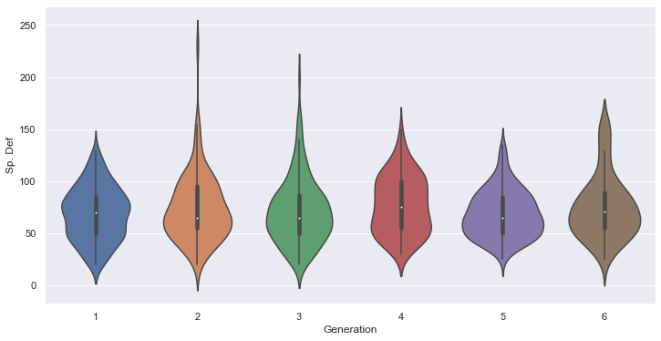

```python
sns.set(rc={"figure.figsize": (12, 6)})
sns.violinplot(x='Generation', y='Sp. Def', data=pokemon)
```

We can see that the average value of the Sp. Def of several generations of Pokémon is not very different, although there are some individuals with extremely large Sp. Def values in the second generation.

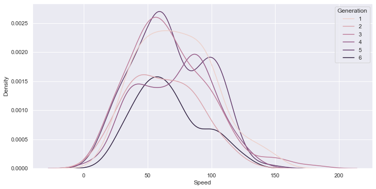

```python
sns.set(rc={"figure.figsize": (12, 6)})
sns.kdeplot(data=pokemon, x="Speed", hue="Generation")
```

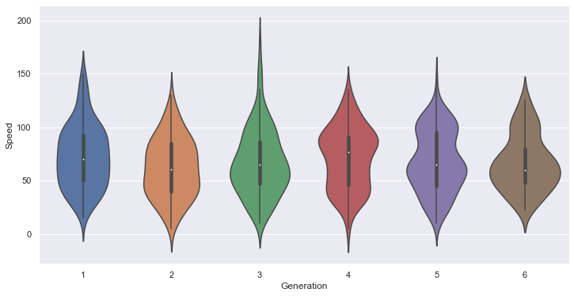

```python
sns.set(rc={"figure.figsize": (12, 6)})
sns.violinplot(x='Generation', y='Speed', data=pokemon)
```

I think the designers did not want to make a particularly big difference in the ability points of several generations of Pokémon, because the median value of the ability points of each generation of Pokémon is at about the same level.  
Only, each ability point in a few generations there may be some great value of individual cases.For example, the first generation and the second generation of Pokémon there are cases of great HP value; the second generation and the third generation of Pokémon there are cases of great Defense value; and so on.

### Q4. For 15 points: Compare the distribution of the overall ability score of regular pokemon and legendary pokemon over different generations using a suitable figure (Hint: We used this type of figure in the lab)

- What can you say about the odds of winning in an encounter between a regular pokemon and a legendary pokemon in general?
- Is there a trend in this relationship over generations?

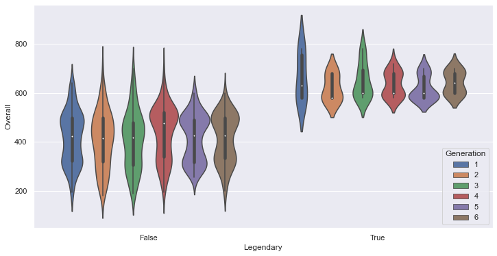

```python
sns.set(rc={"figure.figsize": (12, 6)})
sns.violinplot(x="Legendary", y="Overall", hue="Generation", data=pokemon)
```

We can see that Legendary Pokémon clearly have a higher overall ability point than normal Pokémon. Therefore, when a Legendary Pokémon encounter a regular Pokémon, the former is more likely to win.

With the change of generation, the overall ability points of Pokémon do not show much difference, and the overall ability points of legendary Pokémon are always greater than the overall ability of ordinary Pokémon.

### Q5. For 10 points: Let's explore whether the designers prefer certain types of pokemon when assigning legendary status using the tools you've learnt for categorical variable relationships. Analyse Type 1 and Type 2 separately w.r.t legendary status. What are your observations?

```python
from scipy.stats import chi2_contingency
```

```python
ct = pd.crosstab(pokemon['Type 1'],pokemon['Legendary'])
ct
```

| Legendary Type 1 | False | True |
| --- | --- | --- |
| Bug | 69 | 0 |
| Dark | 29 | 2 |
| Dragon | 20 | 12 |
| Electric | 40 | 4 |
| Fairy | 16 | 1 |
| Fighting | 27 | 0 |
| Fire | 47 | 5 |
| Flying | 2 | 2 |
| Ghost | 30 | 2 |
| Grass | 67 | 3 |
| Ground | 28 | 4 |
| Ice | 22 | 2 |
| Normal | 96 | 2 |
| Poison | 28 | 0 |
| Psychic | 43 | 14 |
| Rock | 40 | 4 |
| Steel | 23 | 4 |
| Water | 108 | 4 |

```python
chi2, p, dof, ex = chi2_contingency(ct)
ex = pd.DataFrame(ex)
ex.index = ['Bug','Dark','Dragon','Electric','Fairy','Fighting','Fire','Flying','Ghost','Grass','Ground','Ice','Normal','Poison','Psychic','Rock','Steel','Water']
ex.columns = ['Ex. False', 'Ex. True']
df = ct.join(ex, on='Type 1')
df
```

| Type 1 | False | True | Ex. False | Ex. True |
| --- | --- | --- | --- | --- |
| Bug | 69 | 0 | 63.39375 | 5.60625 |
| Dark | 29 | 2 | 28.48125 | 2.51875 |
| Dragon | 20 | 12 | 29.40000 | 2.60000 |
| Electric | 40 | 4 | 40.42500 | 3.57500 |
| Fairy | 16 | 1 | 15.61875 | 1.38125 |
| Fighting | 27 | 0 | 24.80625 | 2.19375 |
| Fire | 47 | 5 | 47.77500 | 4.22500 |
| Flying | 2 | 2 | 3.67500 | 0.32500 |
| Ghost | 30 | 2 | 29.40000 | 2.60000 |
| Grass | 67 | 3 | 64.31250 | 5.68750 |
| Ground | 28 | 4 | 29.40000 | 2.60000 |
| Ice | 22 | 2 | 22.05000 | 1.95000 |
| Normal | 96 | 2 | 90.03750 | 7.96250 |
| Poison | 28 | 0 | 25.72500 | 2.27500 |
| Psychic | 43 | 14 | 52.36875 | 4.63125 |
| Rock | 40 | 4 | 40.42500 | 3.57500 |
| Steel | 23 | 4 | 24.80625 | 2.19375 |
| Water | 108 | 4 | 102.90000 | 9.10000 |

For Type 1, the designers especially prefer Dragon and Psychic when assigning legendary status. Electric, Fire, Flying, Ground, Ice, Rock and Steel also have a higher number of Legendary Pokemon than expected.

```python
ct = pd.crosstab(pokemon['Type 2'],pokemon['Legendary'])
ct
```

| Legendary Type 2 | False | True |
| --- | --- | --- |
| Bug | 3 | 0 |
| Dark | 19 | 1 |
| Dragon | 14 | 4 |
| Electric | 5 | 1 |
| Fairy | 21 | 2 |
| Fighting | 22 | 4 |
| Fire | 9 | 3 |
| Flying | 84 | 13 |
| Ghost | 13 | 1 |
| Grass | 25 | 0 |
| Ground | 34 | 1 |
| Ice | 11 | 3 |
| Normal | 4 | 0 |
| Poison | 34 | 0 |
| Psychic | 28 | 5 |
| Rock | 14 | 0 |
| Steel | 21 | 1 |
| Water | 13 | 1 |

```python
chi2, p, dof, ex = chi2_contingency(ct)
ex = pd.DataFrame(ex)
ex.index = ['Bug','Dark','Dragon','Electric','Fairy','Fighting','Fire','Flying','Ghost','Grass','Ground','Ice','Normal','Poison','Psychic','Rock','Steel','Water']
ex.columns = ['Ex. False', 'Ex. True']
df = ct.join(ex, on='Type 2')
df
```

| Type 2 | False | True | Ex. False | Ex. True |
| --- | --- | --- | --- | --- |
| Bug | 3 | 0 | 2.710145 | 0.289855 |
| Dark | 19 | 1 | 18.067633 | 1.932367 |
| Dragon | 14 | 4 | 16.260870 | 1.739130 |
| Electric | 5 | 1 | 5.420290 | 0.579710 |
| Fairy | 21 | 2 | 20.777778 | 2.222222 |
| Fighting | 22 | 4 | 23.487923 | 2.512077 |
| Fire | 9 | 3 | 10.840580 | 1.159420 |
| Flying | 84 | 13 | 87.628019 | 9.371981 |
| Ghost | 13 | 1 | 12.647343 | 1.352657 |
| Grass | 25 | 0 | 22.584541 | 2.415459 |
| Ground | 34 | 1 | 31.618357 | 3.381643 |
| Ice | 11 | 3 | 12.647343 | 1.352657 |
| Normal | 4 | 0 | 3.613527 | 0.386473 |
| Poison | 34 | 0 | 30.714976 | 3.285024 |
| Psychic | 28 | 5 | 29.811594 | 3.188406 |
| Rock | 14 | 0 | 12.647343 | 1.352657 |
| Steel | 21 | 1 | 19.874396 | 2.125604 |
| Water | 13 | 1 | 12.647343 | 1.352657 |

### Q6. For 30 points: Let's try to more concretly analyse if the odds of a legendary pokemon winning was related to the generation they were introduced in. Load the combat encounter dataset and join it with the pokemon dataset to identify the generation and legendary status of each pokemon in an encounter. Considering encounters between legendary pokemon introduced in a given generation and regular pokemon of any generation, create a cross tabulation of generation against the wins/losses of legendary pokemon.

- Are there *statistically significant* differences in the odds of a legendary pokemon winning based on the generation it was introduced in? ($\alpha=0.05$). What do you observe?
- Does this remain true if we limit the encounters to pokemon introduced in the same generation?

```python
pokemon_info = pokemon[["#", "Generation", "Legendary"]]

combats['#'] = combats['First_pokemon']

combats1 = combats.merge(pokemon_info, how='left', on='#')
combats1 = combats1.rename(columns={"Generation":"First_Generation", "Legendary":"First_Legendary"})

combats1['#'] = combats1['Second_pokemon']

combats2 = combats1.merge(pokemon_info, how='left', on='#')
combats2 = combats2.rename(columns={"Generation":"Second_Generation", "Legendary":"Second_Legendary"})

combats2['#'] = combats2['Winner']

combats_final = combats2.merge(pokemon_info, how='left', on='#')
combats_final = combats_final.rename(columns={"Generation":"Winner_Generation", "Legendary":"Winner_Legendary"})

combats_final = combats_final[(((combats_final['First_Legendary'] == True)
                                & (combats_final['Second_Legendary'] == False)) |
                              ((combats_final['First_Legendary'] == False) & (combats_final['Second_Legendary'] == True)))]
combats_final
```

|  | First_pokemon | Second_pokemon | Winner | # | First_Generation | First_Legendary | Second_Generation | Second_Legendary | Winner_Generation | Winner_Legendary |
| --- | --- | --- | --- | --- | --- | --- | --- | --- | --- | --- |
| 7 | 73 | 545 | 545 | 545 | 1 | False | 4 | True | 4 | True |
| 11 | 701 | 624 | 701 | 701 | 5 | True | 5 | False | 5 | True |
| 16 | 143 | 263 | 263 | 263 | 1 | False | 2 | True | 2 | True |
| 51 | 164 | 751 | 751 | 751 | 1 | True | 6 | False | 6 | False |
| 52 | 424 | 754 | 424 | 424 | 3 | True | 6 | False | 3 | True |
| ... | ... | ... | ... | ... | ... | ... | ... | ... | ... | ... |
| 49979 | 540 | 233 | 540 | 540 | 4 | True | 2 | False | 4 | True |
| 49984 | 126 | 425 | 425 | 425 | 1 | False | 3 | True | 3 | True |
| 49985 | 799 | 513 | 513 | 513 | 6 | True | 4 | False | 4 | False |
| 49992 | 592 | 703 | 703 | 703 | 5 | False | 5 | True | 5 | True |
| 49995 | 707 | 126 | 707 | 707 | 5 | True | 1 | False | 5 | True |

7490 rows × 10 columns

```python
ct = pd.crosstab(combats_final.Winner_Legendary, combats_final.Winner_Generation)
ct
```

| Winner_Generation Winner_Legendary | 1 | 2 | 3 | 4 | 5 | 6 |
| --- | --- | --- | --- | --- | --- | --- |
| False | 360 | 158 | 244 | 228 | 325 | 147 |
| True | 640 | 437 | 1570 | 1280 | 1452 | 649 |

```python
chi2, p, dof, ex = chi2_contingency(ct)
p
```

```
4.588546201539536e-53
```

It can be seen that the p-value obtained by chi-square test is very small, less than 0.05. This result indicates that we can reject the null hypothesis that there is no statistical significance in the odds of a legendary Pokemon winning in all generations. Therefore, there is a relationship between whether the Pokemon is legendary and whether it would win.

```python
combats_final2 = combats_final[(combats_final['First_Generation'] == combats_final['Second_Generation'])]
ct = pd.crosstab(combats_final2.Winner_Legendary, combats_final2.Winner_Generation)
ct
```

| Winner_Generation Winner_Legendary | 1 | 2 | 3 | 4 | 5 | 6 |
| --- | --- | --- | --- | --- | --- | --- |
| False | 28 | 10 | 88 | 47 | 56 | 18 |
| True | 124 | 45 | 321 | 195 | 290 | 77 |

```python
chi2, p, dof, ex = chi2_contingency(ct)
p
```

```
0.6163483767305641
```

This time, the p-value obtained by chi-square test is not so small, larger than 0.05. Thus we can not reject the null hypothesis that there is no statistical significance in the odds of a legendary Pokemon winning in the same generations. We cannot say whether there is a relationship between whether the Pokemon is legendary and whether it would win in the same generation.

### Q7. (Ungraded) Let's explore if certain types of Pokemon have a competitive advantage against other types. To simplify the analysis let restrict the Pokemon with only one type (Type 1 and Type 2 are the same). Join the combat encounters data with the filtered Pokemon table to identify Type 1 of each combatant and estimate the win/loss rate of each pair of types (Consider only encounters between different types). In order to account for all encounters between the same two type pairs under one group, order the pairs by alphabetical order (i.e. first type precedes the second type in terms of alphabetical order of type name). Which types of pokemon are effective against most other types of pokemon? (Try to account for amount of data available when interpreting)

# Submission Details:

## Please submit both uniquename_si618_hw8.ipynb and uniqname_si618_hw8.html SEPARATELY on canvas